## Приложения к книге “Введение в статистическое обучение с примерами на языке R”

Этот репозиторий содержит файлы скриптов на языке R и наборы данных, необходимые для выполнение лабораторных работ из книги [*“Джеймс Г., Уиттон Д., Хасти Т., Тибширани Р. Введение в статистическое обучение с примерами на языке R. Пер. с англ. С. Э. Мастицкого - М.: ДМК Пресс, 2016. – 449 с.: ил.”*](http://dmkpress.com/catalog/computer/statistics/978-5-97060-293-5/) (оригинальное название [*“An Introduction to Statistical Learning with Applications in R”*](http://www-bcf.usc.edu/~gareth/ISL/index.html)).

Репозиторий разбит на две директории:

- `Code`: примеры кода для каждой главы
- `Data`: соответствующие наборы данных

В файле `sample.pdf` можно ознакомиться с оглавлением и отрывками из первых двух глав книги.

С вопросами и предложениями по поводу содержания этого репозитория обращайтесь, пожалуйста, по электронной почте.

## Ошибки, обнаруженные в первом издании книги (список обновлен 15 декабря 2016 г.)

К сожалению, после публикации первого издания (апрель 2016 г.) в книге был найден ряд опечаток и ошибок технического характера (огромное спасибо всем читателям, которые сообщили о них!). С их списком можно ознакомиться ниже. Все эти неточности и ошибки будут учтены в последующих изданиях.

- **Опечатки в матрице, представленной вверху на стр. 23**: эта матрица должна выглядеть следующим образом:

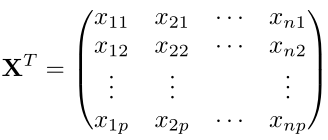

- **Лишнее слово в начале 2-го абзаца на стр. 28**: вместо “…на образование (years of education; …” должно быть “на образование (years; …”
- **Лишнее слово в начале 2-го абзаца на стр. 27**: вместо “…тогда как sales - это выходной переменной…” должно быть “тогда как sales - выходной переменной”
- **Пропущено слово в конце 3-го абзаца на стр. 30**: вместо “…в зависимости условий производства…” должно быть “…в зависимости от условий производства”
- **Опечатка в первом абзаце на стр. 41**: должно быть “…(т.е. переменной с двумя…”
- **Стр. 44-46, рисунки 2.9-2.11 (справа)**: перепутаны подписи осей. Ось X должна быть подписана как “Гибкость”, а ось Y - как “Среднеквадратичная ошибка”
- **Опечатка в 1-м абзаце на стр. 58**: должно быть “…при вызове этой функции…”, а не “…при вызове этой функций…”
- **Опечатка во 2-м абзаце на стр. 58**: должно быть “…воспроизводил один и тот же набор…”, а не “…воспроизводил один тот же набор…”
- **Стр. 58**: Вместо sd() на поля второй раз ошибочно вынесено mean()
- **Опечатка в последнем предложении на стр. 59**: должно быть “…значений y…”, а не “…значения y…”
- **Опечатка в конце 2-го абзаца на стр. 60**: вместо “?controur” должно быть “?contour”
- **Опечатка в 4-м абзаце на стр. 62**: вместо “read.table()” должно быть “read.csv()”
- **Лишнее слово во 2-м абзаце на стр. 65**: вместо “…у нас есть имеется…” должно быть “…у нас имеется…”
- **Опечатка в пункте 9(а) на стр. 69**: вместо “Какие предикторы явлются…” должно быть “Какие предикторы являются…”
- **Стр. 79, 4-я строка сверху, пропущено слово**: вместо “…95-ный доверительный для…” должно быть “…95-ный доверительный интервал для…”
- **Стр. 79, после уравнения (3.13)**: вместо “…против $H_0:$ …” должно быть “…против $H_a:$ …”
- **Опечатка на стр. 84, после уравнения (3.19)**: вместо “$b_j$” дожно быть “$beta_j$”
- **Опечатки на стр. 92, 3-й абзац сверху**: 1) вместо “…при добавлении newspapers в модель…” должно быть “…при добавлении newspaper в модель…”; 2) вместо “…p–значение для radio было незначимым.” должно быть “p–значение для newspaper было незначимым.”
- **Стр. 92, последний абзац**: первое предложение в этом абзаце должно выглядеть следующим образом: “RSE у модели, содержащей в качестве предикторов только TV и radio, составляет 1.681, а у модели, которая включает также newspaper, RSE = 1.686 (табл. 3.6).”
- **Стр. 99**: заголовок “Расширения линейной модели” должен быть заголовком подраздела, “3.3.2 Расширения линейной модели”
- **Стр. 100, уравнение (3.32)**: член “beta_3 X_1 X_2” после первого знака “=” лишний.
- **Стр. 102, уравнение (3.34)**: это уравнение должно выглядеть следующим образом:

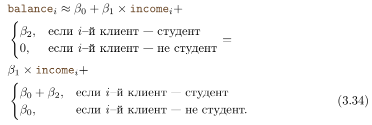

Уравнение 3.34

- **Стр. 105, неверная нумерация подраздела**: вместо “3.3.1 Потенциальные проблемы” должно быть “3.3.3 Потенциальные проблемы”
- **Стр. 110, последний абзац**: слово “этого” в последнем предложении лишнее.
- **Стр. 111, рисунок 3.11 (справа)**: опечатка в подписи оси Х. Вместо “Показтель” должно быть “Показатель”
- **Опечатка на стр. 112, 4-я строка снизу**: вместо “…этом рисунке…” должно быть “…на этом рисунке…”
- **Опечатка на стр. 114, 2-й абзац снизу**: вместо “…для каждого предиктора рассчитывает путем…” должно быть “…для каждого предиктора рассчитывается путем…”
- **Стр. 115, таблица 3.11**: эта таблица должна выглядеть следующим образом:

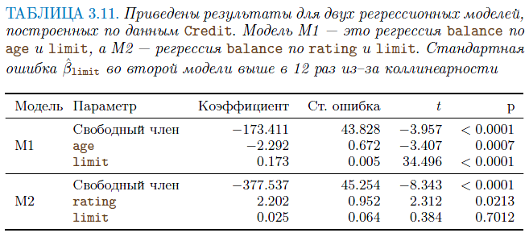

Таблица 3.11

- **Опечатка на стр. 116, 12-я строка сверху**: должно быть “минимально” вместо “минимиально”
- **Опечатка на стр. 117, 2-я строка сверху**: должно быть “реклама на телевидении” вместо “реклама не телевидении”
- **Опечатка на стр. 117, 2-й абзац**: вместо “…с количеством продажам.” должно быть “…с количеством продаж.”
- **Стр. 122, подпись к рис. 3.19**: эта подпись ошибочно была скопирована с подписи к рис. 3.18. Правильная подпись должна выглядеть следующим образом:

“Слева вверху: Приведены KNN–модели с K = 1 (голубая кривая) и K = 9 (красная кривая) для случая со слабой нелинейной зависимостью между X и Y (черная сплошная кривая). Справа вверху: Показаны MSE на контрольной выборке для линейной регрессии по методу наименьших квадратов (горизонтальная черная линия) и для KNN–моделей с разными значениями 1/K (зеленая кривая), подогнанных к данным со слабой нелинейной зависимостью. Слева и справа внизу: То же, что и вверху, но для случая с выраженной нелинейной зависимостью между X и Y”